# act_report

## Report: act_report

Dogs are amazing! From puppo, doggo, floofer, pupper, the dog stages, to the various dog breeds. After gathering, cleaning and analysing the three dataset produced, the following insights were gotten.

### The dog stage with the highest average dog rating.

Puppo emerged as the dog stage with the highes average rating. It was a fierce battle between puppo and doggo but somehow puppo managed to win. It was almost a tie

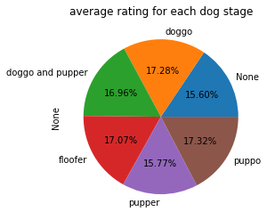

### The dog breed with the highest average dog rating

It's about time to salute the salukis! The saluki dog breed emerged the dog breed with the highest average dog rating

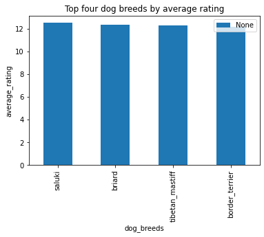

### Number of tweets per year

The number of tweets by year saw an increase in 2016; from 436 in 2015 to 736 in 2016. But it decreased significantly in 2017 with 288 number of tweets. It could be that all the tweets from 2017 was not gathered

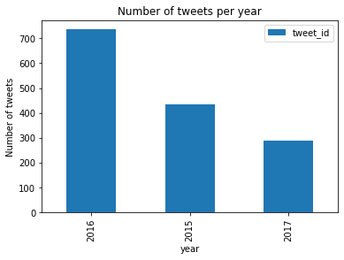

### The year with the highest average dog rating

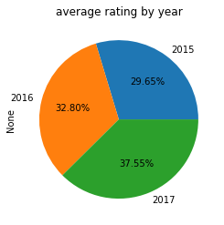

> So adding the ratings from WeRateDog, the favorite counts and the retweeted counts of each dog tweet, I created what I called the overall dog rating. haha!

### 2015 overall best dog

And it's [Pipsy!](https://t.co/h9R0EwKd9), a toy poodle, the overall best dog for the year 2015 with an overall rating of 68017

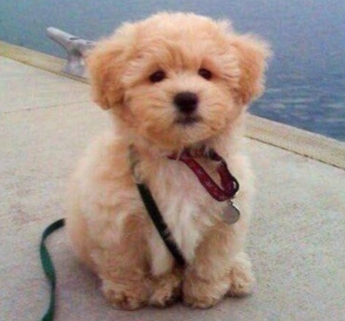

### 2016 overall best dog

A [doggo](https://t.co/7wE9LTEXC4) and a labrador retriever with an overall rating of 210603. Unforfunately, the name of the dog was not given.

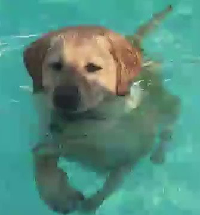

### 2017 overall best dog

An outstanding [puppo](https://t.co/nTz3FtorBc) with an overall rating of 181088, loved and cherished by others is the overall best dog for 2017. It is a lakelan terrier.

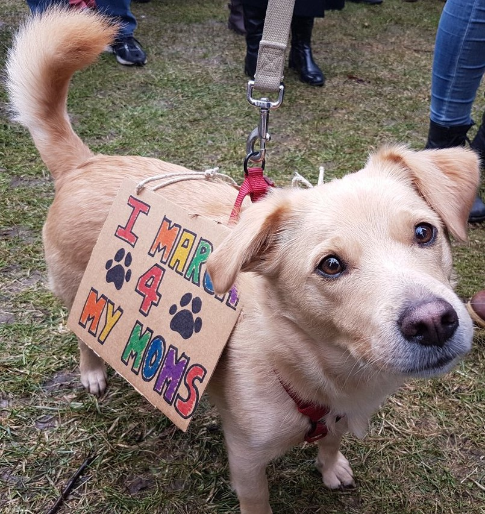

> Can I tell you a truth? I fell in love with dogs after analysing these data. haha! bye for now